# Chapter-9-ExerciseSolutions

4. Conduct a nonparametric two-sample test for the hypothesis that the median value of Balance is the same for Blue Collar and White Collar customers.

```r
bk = data.table(readr::read_csv('../../data/UK-Bank-Customers.csv', show_col_types = FALSE))

head(bk)
```

```
##    Customer ID    Name Surname Gender Age           Region Job Classification
## 1:   100000001   Simon   Walsh   Male  21          England       White Collar
## 2:   400000002 Jasmine  Miller Female  34 Northern Ireland        Blue Collar
## 3:   100000003    Liam   Brown   Male  46          England       White Collar
## 4:   300000004  Trevor    Parr   Male  32            Wales       White Collar
## 5:   100000005 Deirdre Pullman Female  38          England        Blue Collar
## 6:   300000006     Ava Coleman Female  30            Wales        Blue Collar
##    Date Joined   Balance
## 1:   05.Jan.15 113810.15
## 2:   06.Jan.15  36919.73
## 3:   07.Jan.15 101536.83
## 4:   08.Jan.15   1421.52
## 5:   09.Jan.15  35639.79
## 6:   09.Jan.15 122443.77
```

```r
bl_col <- bk[`Job Classification` == "Blue Collar"]

head(bl_col)
```

```
##    Customer ID    Name Surname Gender Age           Region Job Classification
## 1:   400000002 Jasmine  Miller Female  34 Northern Ireland        Blue Collar
## 2:   100000005 Deirdre Pullman Female  38          England        Blue Collar
## 3:   300000006     Ava Coleman Female  30            Wales        Blue Collar
## 4:   100000007 Dorothy Thomson Female  34          England        Blue Collar
## 5:   100000019 William    Ince   Male  40          England        Blue Collar
## 6:   100000020  Audrey   Jones Female  46          England        Blue Collar
##    Date Joined   Balance
## 1:   06.Jan.15  36919.73
## 2:   09.Jan.15  35639.79
## 3:   09.Jan.15 122443.77
## 4:   11.Jan.15  42879.84
## 5:   15.Jan.15  65534.69
## 6:   15.Jan.15  11462.64
```

```r
median(bl_col$Balance)
```

```
## [1] 35639.79
```

```r
wt_col <- bk[`Job Classification` == "White Collar"]

head(wt_col)
```

```
##    Customer ID    Name  Surname Gender Age  Region Job Classification
## 1:   100000001   Simon    Walsh   Male  21 England       White Collar
## 2:   100000003    Liam    Brown   Male  46 England       White Collar
## 3:   300000004  Trevor     Parr   Male  32   Wales       White Collar
## 4:   300000009    Ruth Campbell Female  33   Wales       White Collar
## 5:   100000010 Dominic     Parr   Male  42 England       White Collar
## 6:   100000011 Dominic    Lewis   Male  40 England       White Collar
##    Date Joined   Balance
## 1:   05.Jan.15 113810.15
## 2:   07.Jan.15 101536.83
## 3:   08.Jan.15   1421.52
## 4:   11.Jan.15  74284.35
## 5:   12.Jan.15  10912.45
## 6:   12.Jan.15  39667.83
```

```r
median(wt_col$Balance)
```

```
## [1] 28587.08
```

null hypothesis : Median of Blue and White collar employees are the same Since there is no correlation, we can shuffle the vectors and find their correlation to create a sampling distribution. Create a sampling distribution.

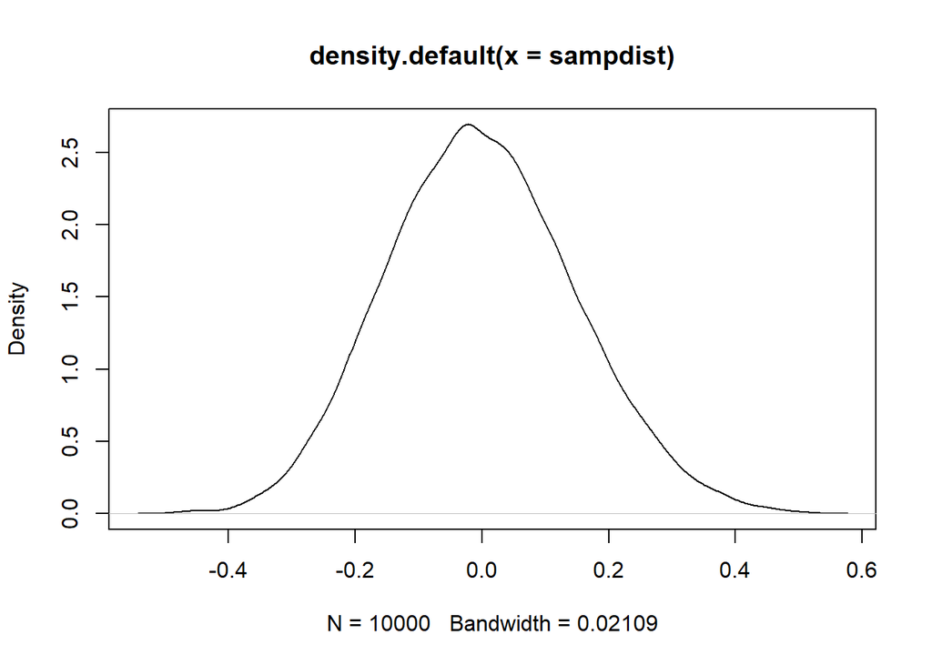

```r
sampdist <- vector()

for (i in 1:10000) {

  s1 <- sample(bl_col$Balance, size = nrow(bl_col))
  s2 <- sample(bl_col$Balance, size = nrow(bl_col))

  sampdist <- append(sampdist, cor(s1, s2, method = "pearson"))

}

plot(density(sampdist))
```

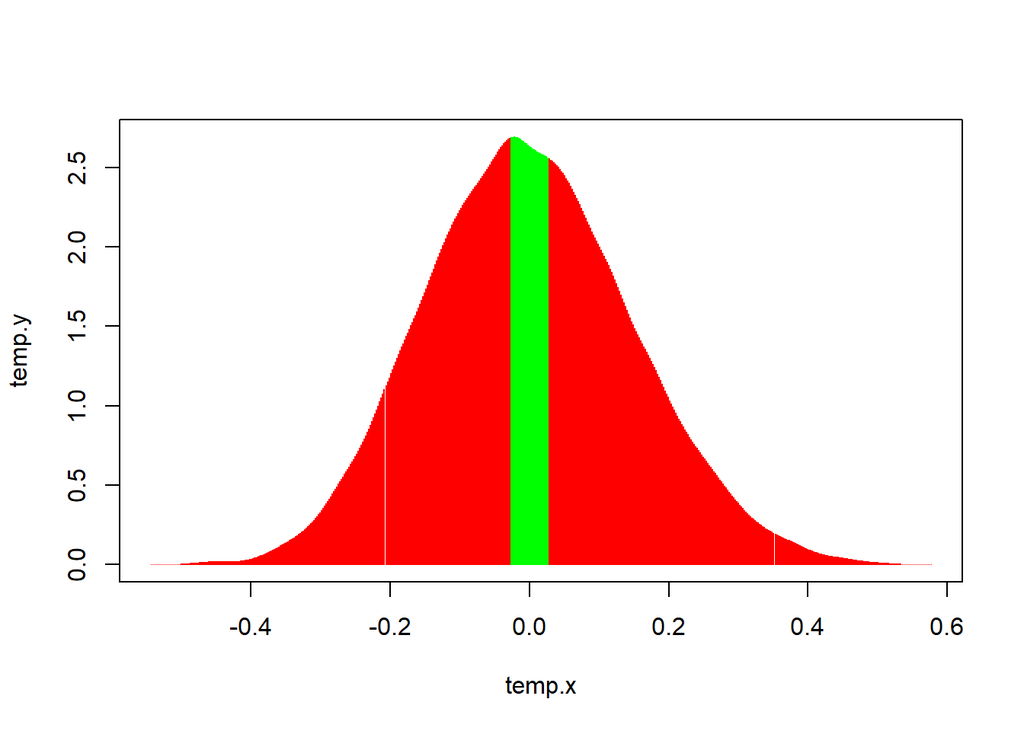

```
## [1] 0.8559
```

```r
tstat <- cor(bl_col$Balance, sample(wt_col$Balance, size = nrow(bl_col)), method = "pearson")

p_2tail(sampdist, tstat)
```

5. Use bootstrapping to create the 99% confidence interval for the median value of Balance for Female customers.

```r
fe <- bk[Gender == "Female"]
head(fe)
```

```
##    Customer ID    Name  Surname Gender Age           Region Job Classification
## 1:   400000002 Jasmine   Miller Female  34 Northern Ireland        Blue Collar
## 2:   100000005 Deirdre  Pullman Female  38          England        Blue Collar
## 3:   300000006     Ava  Coleman Female  30            Wales        Blue Collar
## 4:   100000007 Dorothy  Thomson Female  34          England        Blue Collar
## 5:   300000009    Ruth Campbell Female  33            Wales       White Collar
## 6:   100000020  Audrey    Jones Female  46          England        Blue Collar
##    Date Joined   Balance
## 1:   06.Jan.15  36919.73
## 2:   09.Jan.15  35639.79
## 3:   09.Jan.15 122443.77
## 4:   11.Jan.15  42879.84
## 5:   11.Jan.15  74284.35
## 6:   15.Jan.15  11462.64
```

```r
bootsampdist <- vector()

for (i in 1:10000) {

  s1 <- mean(sample(fe$Balance, size = nrow(fe), replace = T))

  bootsampdist <- append(bootsampdist, s1)

}

q2 <- quantile(bootsampdist, c(.01/2, 1-(.01/2)))

print(paste0("99% Confidence interval = [", round(q2[1],2), ", ", round(q2[2],2), "]"))
```

```
## [1] "99% Confidence interval = [29196.13, 48888.24]"
```

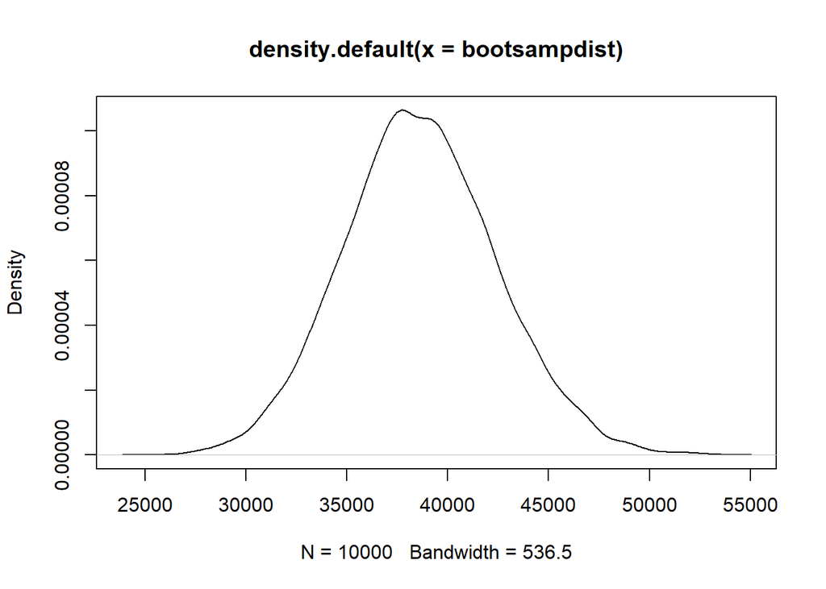

```r
plot(density(bootsampdist))
```

Read the file Baseball.csv

Use bootstrapping to create the 95% confidence interval for the interquartile range of the variable Average. The interquartile range is the difference between the 75% and 25% percentile values.

```r
bb <- data.table(readr::read_csv('../../data/Baseball.csv', show_col_types = FALSE))

head(bb)
```

```
##        Name  Salary Average
## 1:     Matt 9500000   0.269
## 2:      jim 8000000   0.282
## 3:      jim 7333333   0.327
## 4:     fred 7250000   0.259
## 5: jermaine 7166667   0.240
## 6:    edgar 7086668   0.270
```

```r
bootsampdist <- vector()

for (i in 1:10000) {

  s1 <- mean(sample(bb$Average, size = nrow(bb), replace = T))

  bootsampdist <- append(bootsampdist, s1)

}

q2 <- quantile(bootsampdist, c(.05/2, 1-(.05/2)))

print(paste0("99% Confidence interval = [", round(q2[1],2), ", ", round(q2[2],2), "]"))
```

[output not shown]

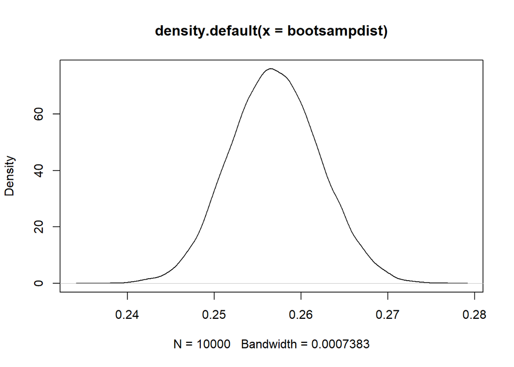

```r
plot(density(bootsampdist))
```

Read the file Health.csv.

7.There is a variable called faminc, which indicates the income of the family. Conduct a test for the median value of 1.75 using both parametric and nonparametric tests.

```r
hl <- data.table(readr::read_csv('../../data/Health.csv', show_col_types = FALSE))

head(hl)
```

```
##    ofp ofnp opp opnp emr hosp exclhlth poorhlth numchron adldiff noreast
## 1:   5    0   0    0   0    1        0        0        2       0       0
## 2:   1    0   2    0   2    0        0        0        2       0       0
## 3:  13    0   0    0   3    3        0        1        4       1       0
## 4:  16    0   5    0   1    1        0        1        2       1       0
## 5:   3    0   0    0   0    0        0        0        2       1       0
## 6:  17    0   0    0   0    0        0        1        5       1       0
##    midwest west age black male married school faminc employed privins medicaid
## 1:       0    0 6.9     1    1       1      6 2.8810        1       1        0
## 2:       0    0 7.4     0    0       1     10 2.7478        0       1        0
## 3:       0    0 6.6     1    0       0     10 0.6532        0       0        1
## 4:       0    0 7.6     0    1       1      3 0.6588        0       1        0
## 5:       0    0 7.9     0    0       1      6 0.6588        0       1        0
## 6:       0    0 6.6     0    0       0      7 0.3301        0       0        1
```

```r
t.test(hl$faminc, mu = 1.75)
```

```
##
##  One Sample t-test
##
## data:  hl$faminc
## t = 17.638, df = 4405, p-value < 0.00000000000000022
## alternative hypothesis: true mean is not equal to 1.75
## 95 percent confidence interval:
##  2.440751 2.613513
## sample estimates:
## mean of x
##  2.527132
```

```r
wilcox.test(hl$faminc, mu = 1.75)
```

```
##
##  Wilcoxon signed rank test with continuity correction
##
## data:  hl$faminc
## V = 5651422, p-value < 0.00000000000000022
## alternative hypothesis: true location is not equal to 1.75
```

8.There are two variables named males and ofp. The second variable refers to the number of office visits made by the patients. Conduct a non-parametric two sample test for the hypothesis that the mean of ofp is the same for both males and females.

```r
hl_ml <- hl[male == 1]
hl_fe <- hl[male == 0]

print(summary(hl_ml$ofp))
```

```
##    Min. 1st Qu.  Median    Mean 3rd Qu.    Max.
##    0.00    1.00    4.00    5.42    7.00   89.00
```

```r
print(summary(hl_fe$ofp))
```

```
##    Min. 1st Qu.  Median    Mean 3rd Qu.    Max.
##   0.000   2.000   4.000   6.014   8.000  61.000
```

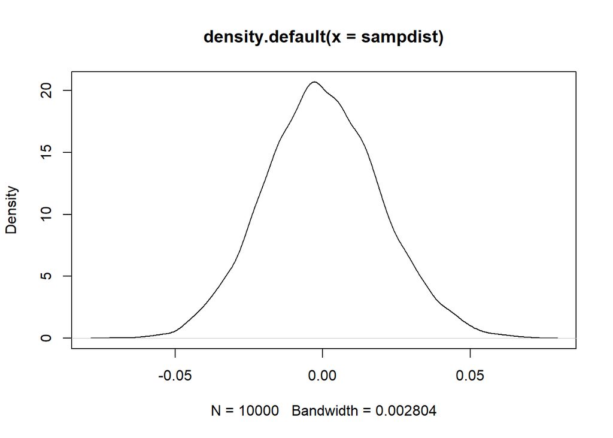

```r
sampdist <- vector()

for (i in 1:10000) {

  s1 <- sample(hl_fe$ofp, size = nrow(hl_fe))
  s2 <- sample(hl_fe$ofp, size = nrow(hl_fe))

  sampdist <- append(sampdist, cor(s1, s2, method = "pearson"))

}

plot(density(sampdist))
```

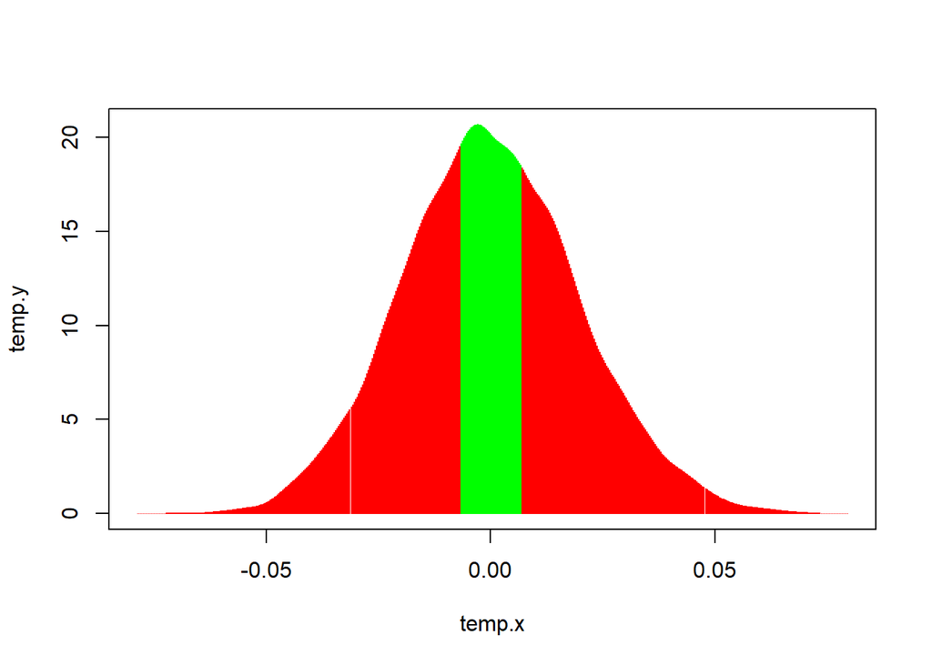

```
## [1] 0.7258
```

```r
tstat <- cor(hl_ml$ofp, sample(hl_fe$ofp, size = nrow(hl_ml)), method = "pearson")

p_2tail(sampdist, tstat)
```